# R Notebook

This is a simple [R Markdown](http://rmarkdown.rstudio.com) Notebook. When you execute code within the notebook, the results appear beneath the code.

## Chicago Weather from weather stations

The URLs for data are on the portal https://data.cityofchicago.org/

In particular the hourly data from the three beach weather stations has a Base URL: https://data.cityofchicago.org/resource/7edu-s3u7.json The API documentation for this dataset is at: https://dev.socrata.com/foundry/data.cityofchicago.org/77jv-5zb8

```r
df <- read.csv("https://data.cityofchicago.org/resource/7edu-s3u7.csv")
```

[output not shown]

Unfortunately the web-service only lets you download 1000 observations in this way and displays the Date/Time with AM/PM which is near impossible to deal with in R.

Barometric pressure for 2017: https://data.cityofchicago.org/resource/77jv-5zb8.csv

```r
library("RSocrata")
fdf <- read.socrata("https://data.cityofchicago.org/resource/7edu-s3u7.csv?$where=station_name=\"Foster Weather Station\"")
```

THis query read 6469 observations of 18 variables. Let’s do the same with the other two stations.

```r
odf <- read.socrata("https://data.cityofchicago.org/resource/7edu-s3u7.csv?$where=station_name=\"Oak Street Weather Station\"")

sdf <- read.socrata("https://data.cityofchicago.org/resource/7edu-s3u7.csv?$where=station_name=\"63rd Street Weather Station\"")
```

Let’s backup this data as *.rda files… just in case.

```r
save(fdf, file = "fdf.rda")
save(odf, file = "odf.rda")
save(sdf, file = "sdf.rda")
```

Also, let’s download everything that can be downloaded directly from the web as a *.csv and re-save it in Excel, in case some weird formatting will get in the way. We will also have a combined data frame then and will be able to assign a category to a weather station and use it later in graphics. It is in the directory, stored as: “Beach_Weather_Stations_-*Automated_Sensors*-*2016*-_Humidity.csv" Downloaded and added the same for 2015 and the “Beach_Water_and_Weather_Sensor_Locations_-_Map.csv" file with the locations of the sensors.

Now we can attempt plotting a little bit

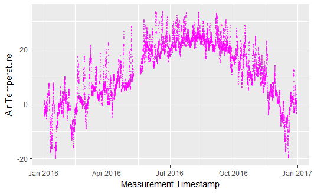

```r
library("ggplot2", lib.loc="~/R/win-library/3.3")
qplot(Measurement.Timestamp, Air.Temperature, data = fdf, color = I("magenta"),
      size = I(.5), alpha = I(1/2))
```

As we can see ggplot2 ‘understands’ our Date/Time format. Interestingly enough there is a gap in data in May.

```r
qplot(Measurement.Timestamp, Air.Temperature, data = sdf, color = I("red"),
      size = I(.5), alpha = I(1/2))
```

[output not shown]

```r
qplot(Measurement.Timestamp, Air.Temperature, data = odf, color = I("green"),
      size = I(.5), alpha = I(1/2))
```

[output not shown]

The direct observation of data shows that indeed the gap (starting after May 9, 13:00 and until May 19 10am) exists.

All together Now!

```r
#df will be re-used for complete data set
df <- read.csv("Beach_Weather_Stations_-_Automated_Sensors_-_2016_-_Humidity.csv")
qplot(Measurement.Timestamp, Air.Temperature, data = df, colour = Station.Name)
```

[output not shown]

Not exactly OK with the Dates that were read from the *.csv file. There is no gap on the time scale which probably means that time is a factor. Even the number of observations doesn’t match the sum of the observations obtained from the Socrata warehouse.

Let’s start with the dates

```r
# we need
# to deal with date-time that is represented by a factor after
# loading. Let's append four columns to the data frame, then
# position them after the Measurement.Timestamp.

  df$Hour <-0; df$Day <- 0; df$Month <- 0
  df <- df[,c("Station.Name",
                        "Measurement.Timestamp",
                        "Hour", "Day", "Month",
                        "Air.Temperature",
                        "Wet.Bulb.Temperature", "Humidity",
                        "Rain.Intensity", "Interval.Rain",
                        "Total.Rain", "Precipitation.Type",
                        "Wind.Direction", "Wind.Speed",
                        "Maximum.Wind.Speed", "Barometric.Pressure",
                        "Solar.Radiation", "Heading",
                        "Battery.Life",
                        "Measurement.Timestamp.Label",
                        "Measurement.ID")]

#Then we convert the Measurement.Timestamp to character
#then - to POSIXlt

  df$Measurement.Timestamp <- as.character.POSIXt(df$Measurement.Timestamp)
  df$Measurement.Timestamp <- as.POSIXlt(df$Measurement.Timestamp,
                                 format = "%m/%d/%Y %H:%M", tz="")

## about dates format: http://www.stat.berkeley.edu/classes/s133/dates.html
# fill in the columns Hour Day (day of the year mday for anthr) Month

  df$Hour <- df$Measurement.Timestamp$hour
  df$Day <- df$Measurement.Timestamp$yday
  df$Month <- df$Measurement.Timestamp$mon

# now let's save the result

  save(df, file = "df.rda")
```

Along the way I added the numbers of the Hour, Day and Month (starting from zero) for accumulation (later). Now let’s try to re-plot the same

```r
qplot(Measurement.Timestamp, Air.Temperature, data = df, colour = Station.Name)
```

[output not shown]

Now the 10-day gap is in place. Let’s massage the graph a little bit

```r
qplot(Measurement.Timestamp, Air.Temperature, data = df, size = I(.7), alpha = I(1/2), colour = Station.Name)
```

[output not shown]

From here we will go in two directions:

1. Chapter “NOAA data” is devoted to getting some historical data from NOAA ASOS ground stations in order to fill the gap with missing data;
2. Chapter “Weather data analysis” will be a description of simple observations based on the available data.